# HAS: Qualtrics Demographic with Subject 438

Shuying Yu

6/21/2022

# Introduction

Data of the *cleaned* sample of Healthy Aging Participants, meaning that these are participants that we have decided to include based on complete fMRI scans, no major health problems from demographic survey, and from previous team discussions of who to exclude as we wrapped up recruitment for the study.

Subjects ranged from 301-437, scanned over the course of March 1, 2017 to February 10, 2022.

Please refer to hand out for means and standard deviations of the basic demographic and neurpsychological batteries. Figures will only include basic demographic and neurpsychiatric batteries.

# Basic Demographics

Age (years), BMI, highest completed level of education (years), and verbal IQ

**Age:** Ranges from 43-60 years old

**BMI:** Healthy adult BMI levels are about 19-25

**Education:**

- Some College or Associate’s = 14 years
- Bachelor’s = 16 years
- Master’s = 18 years
- Doctoral = 20 years

## Reproductive Status

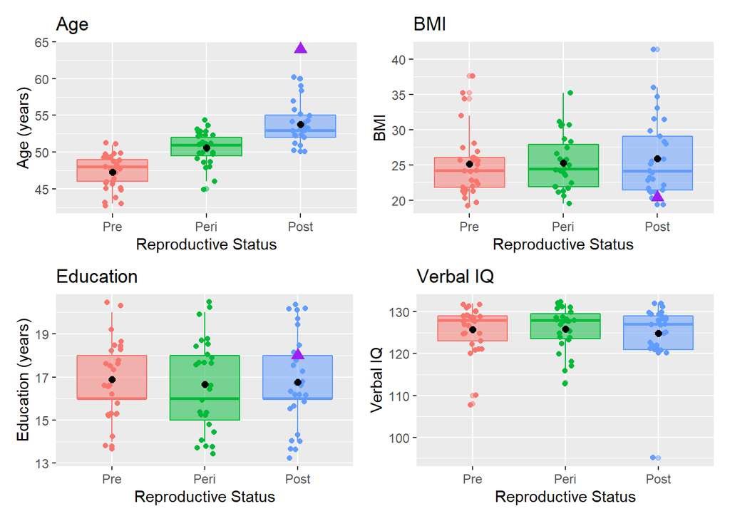

Suject 438:

- Age: 64 years old
- BMI: 20.4
- Education: Master’s degree (18 years of education)

Subject 438 did not do AMNART for Verbal IQ.

## Sex

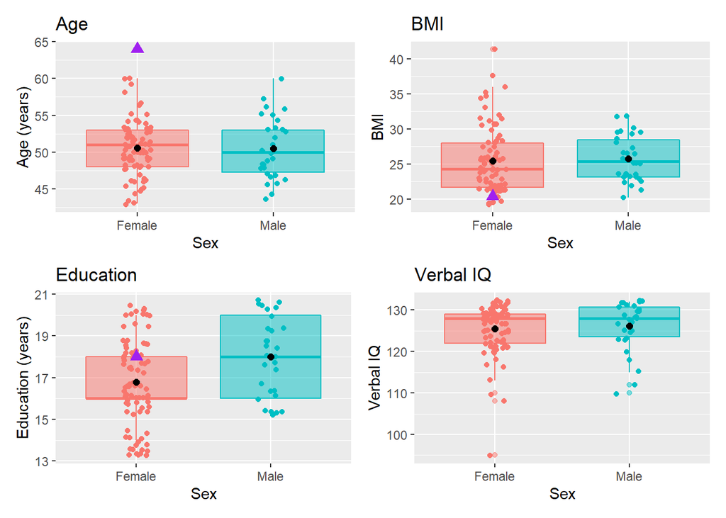

## Total

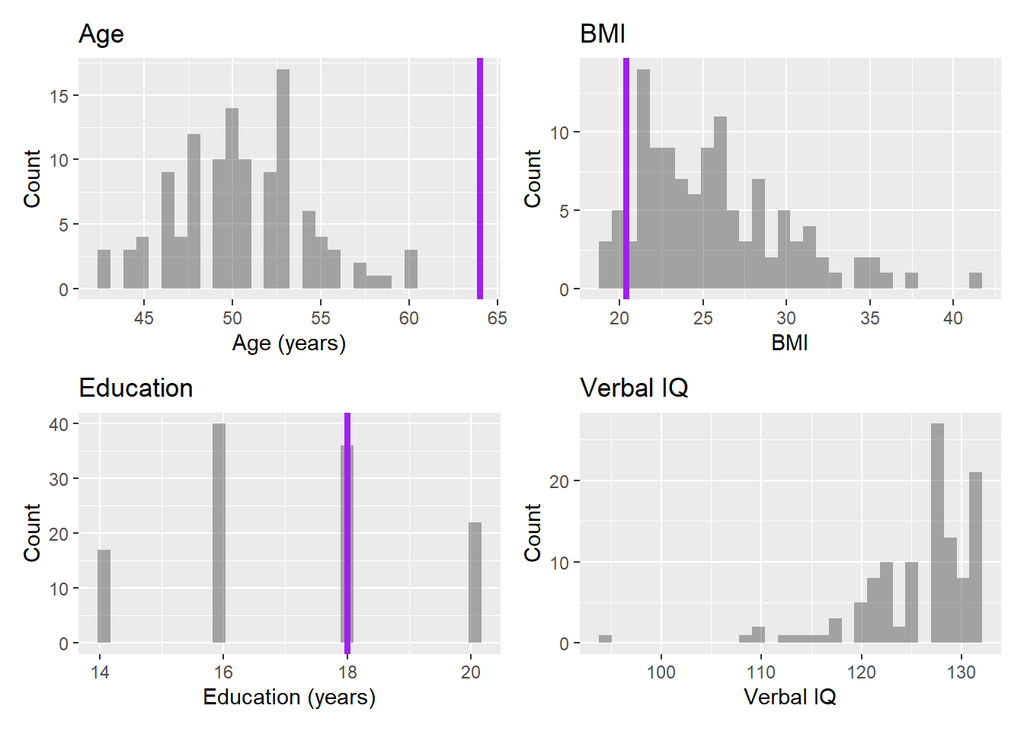

# Neuropsychiatric Assessments

## Edinburgh Handedness

Measures handedness (most are right handed)

- Score of -1.0 = Pure Left Hander
- Score of -0.5 = Mixed Left Hander
- Score of 0.0 = Neutral
- Score of +0.5 = Mixed Right Hander
- Score of +1.0 = Pure Right Hander

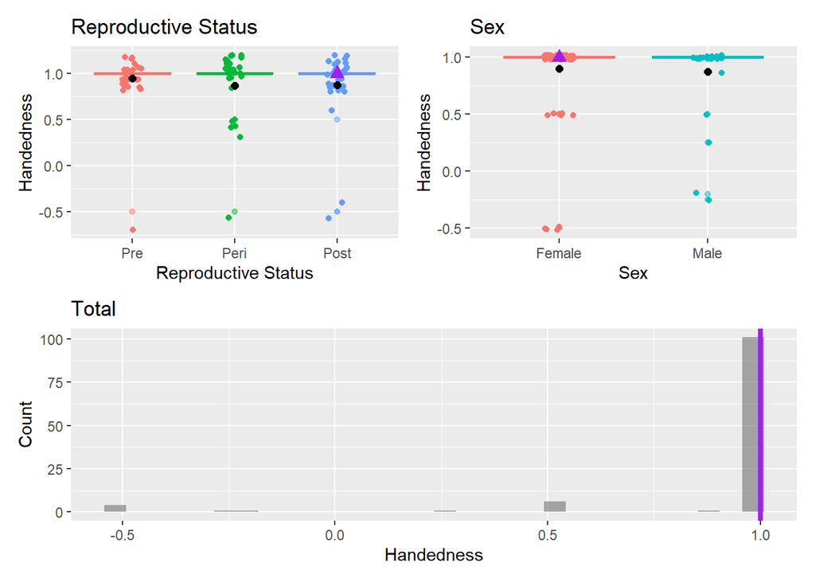

Subject 438: score of 1.0 (pure right hander)

## Epworth Sleepiness

Measures whether participant is abnormally sleepy

- Score of 0-7 = Unlikely to be abnormally sleepy
- Score of 8-9 = Average amount of daytime sleepiness
- Score of 10-15 = May be excessively sleepy depending on situation
- Score of 16-24 = Excessively sleepy

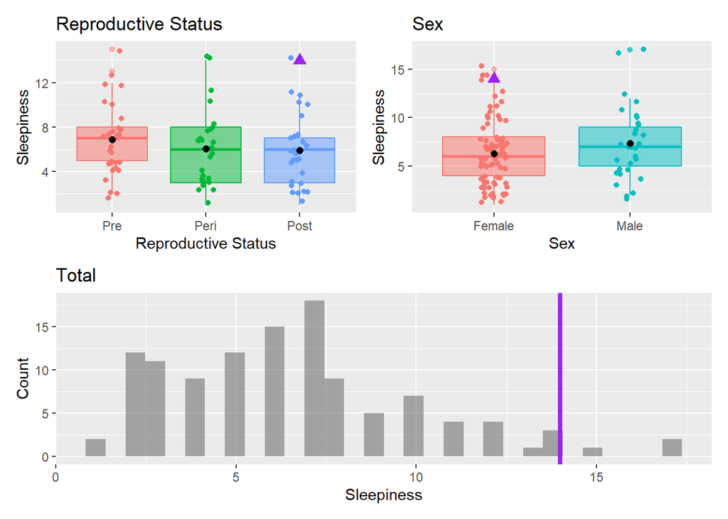

Subject 438: score of 14

## Barratt

Measures personality and behavior impulsivity. Higher scores indicate more impulsivity.

**Overall/Total**

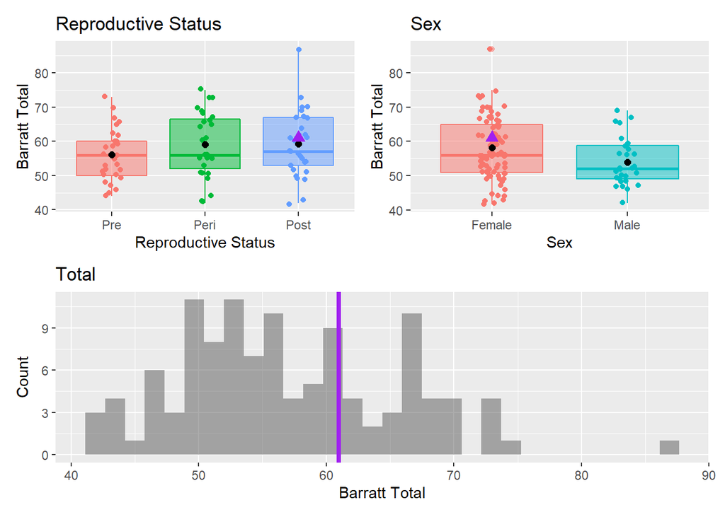

Subject 438: score of 61

## Medical Outcomes

General health index of participants. Scores are the weighted sums of the questions in each section

- Lower scores = more disability
- Higher scores = less disability

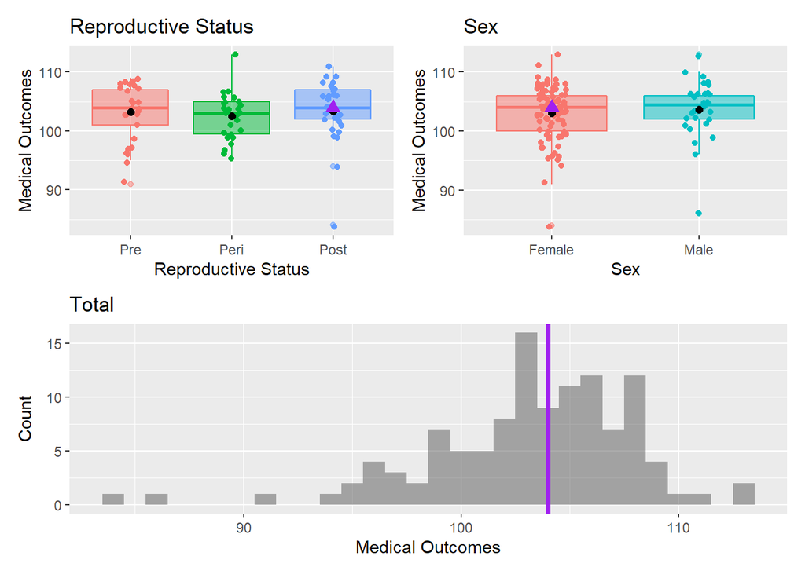

Subject 438: score of 104

## BAS & BIS

Total is the composite score for BAS, which is the sum of scores from the three subscales

- Higher scores = higher motivation for goal-oriented outcomes

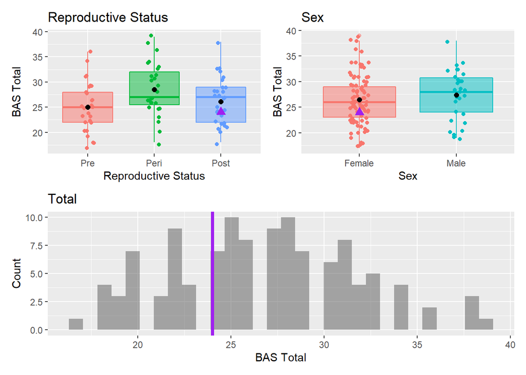

Subject 438: score of 24

**Behavioral Inhibition Scale (BIS) Total** measures motivation to avoid aversive outcomes

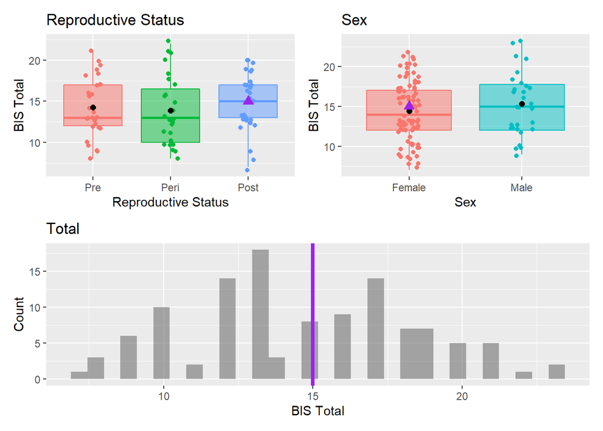

Subject 438: score of 15

## Perceived Stress

Measures participant’s perceived stress. There is a potential relationship with perceived stress and health; Cohen et al. (1988) show correlations with PSS and: Stress Measures, Self-Reported Health and Health Services Measures, Health Behavior Measures, Smoking Status, Help Seeking Behavior.

- Higher scores = more perceived stress

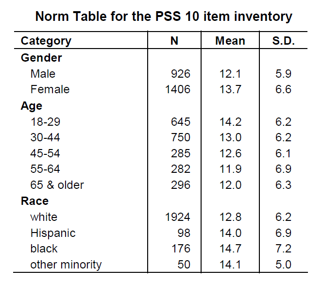

L. Harris Poll gathered information on 2,387 respondents in the U.S. for normative data (from Sheldon Cohen, 1994)

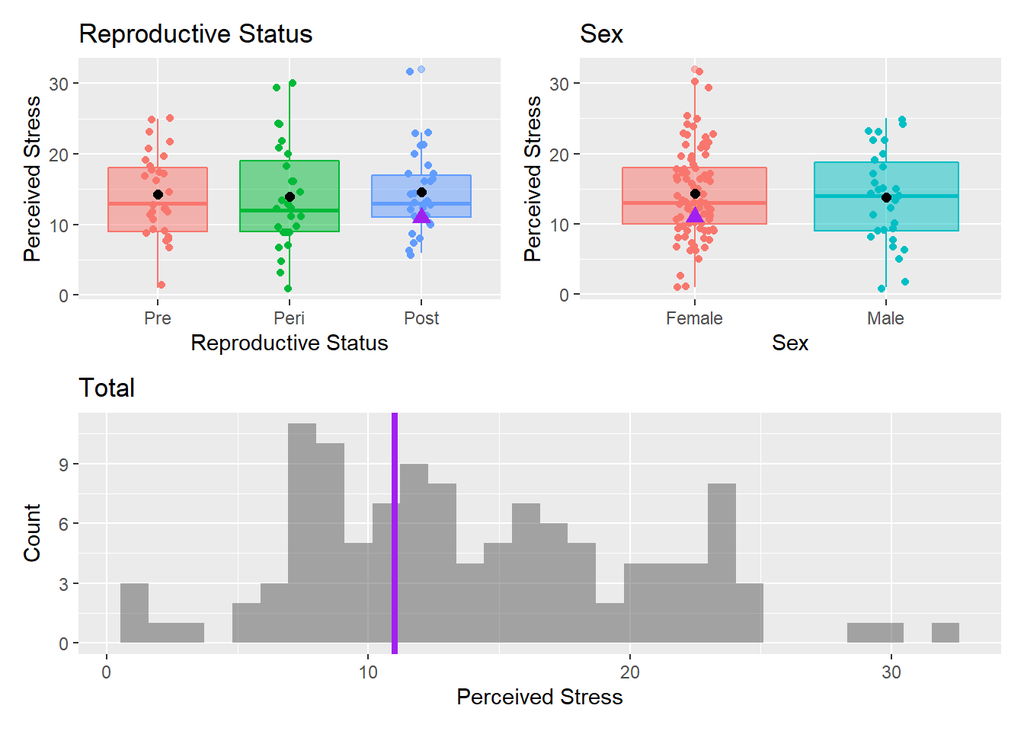

Subject 438: score of 11

## SSS Community Ladder

Measures the participant’s perceived social standing within their community. Scores range from 1-10.

- Higher scores = more perceived social standing

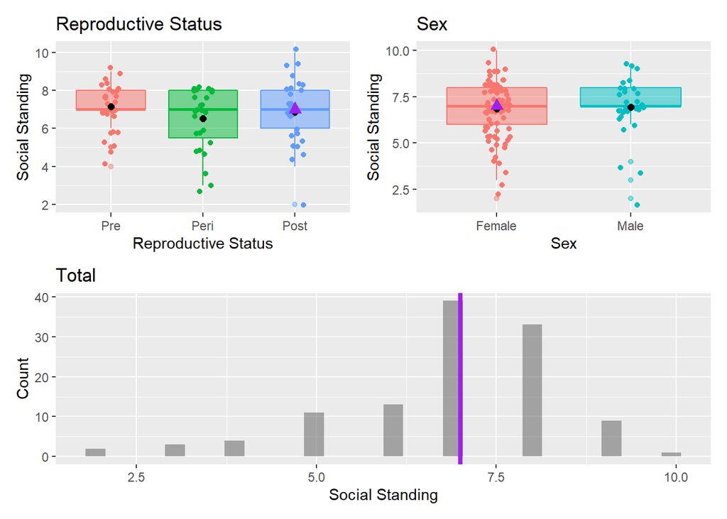

Subject 438: score of 7

## SSS US Ladder

Measures the participant’s perceived social standing within the United States. Scores range from 1-10.

- Higher scores = more perceived social standing

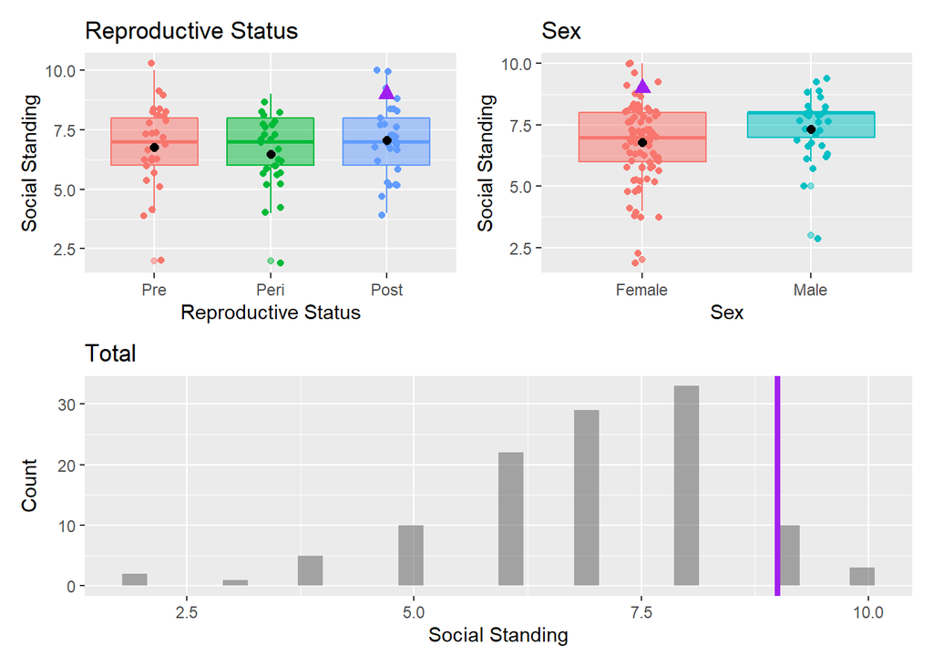

Subject 438: score of 9

## Geriatric Depression

Measures participant depression

- Scores ranging 0-5 are considered normal
- Scores that are 5+ suggest depression

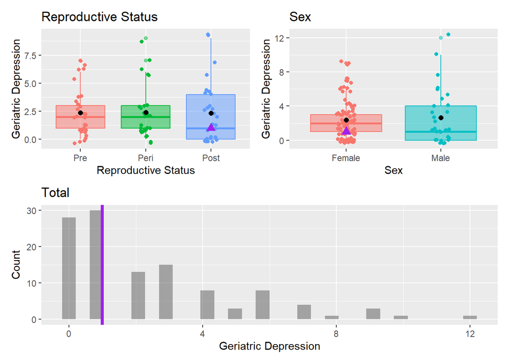

Subject 438: score of 1

Scale was developed by Sheikh & Yesavage, 1986. Times are a lot different now and there is lots to be sad about (i.e., general depression is normalized)

## PSQI

Pittsburgh Sleep Quality Index. Measures quality of sleep by taking into account 7 components: habitual sleep efficiency, subjective sleep quality, sleep duration, sleep latency, use of sleep medications, sleep disturbances, and daytime dysfunction.

Each component is given a score from 0-3, with 0 meaning no difficulty and 3 meaning having severe difficulty.

The PSQI score thus ranges from 0-21:

- Scores of 0 = No difficulty sleeping
- Score of 21 = Severe difficulties in all components/areas

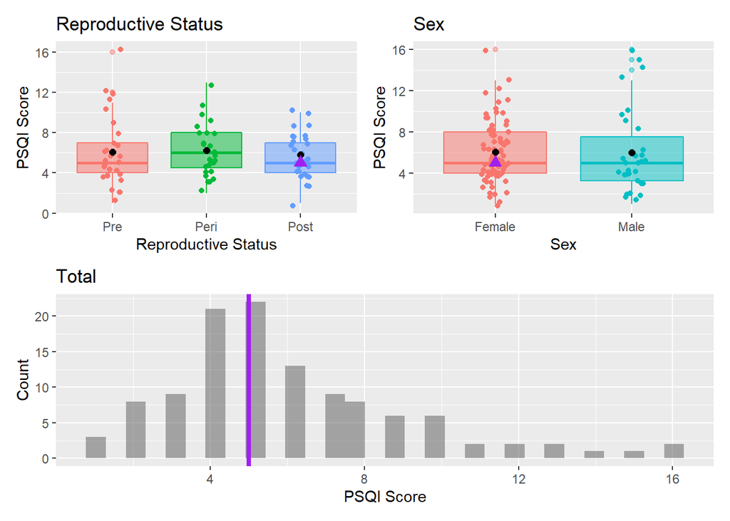

Subject 438: score of 5

# Hormones

## Estradiol

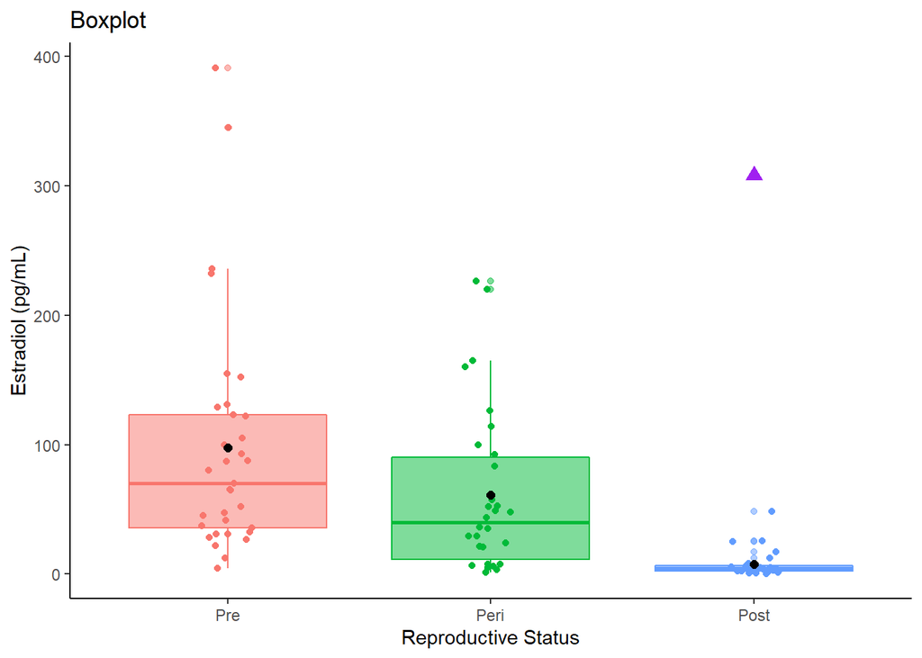

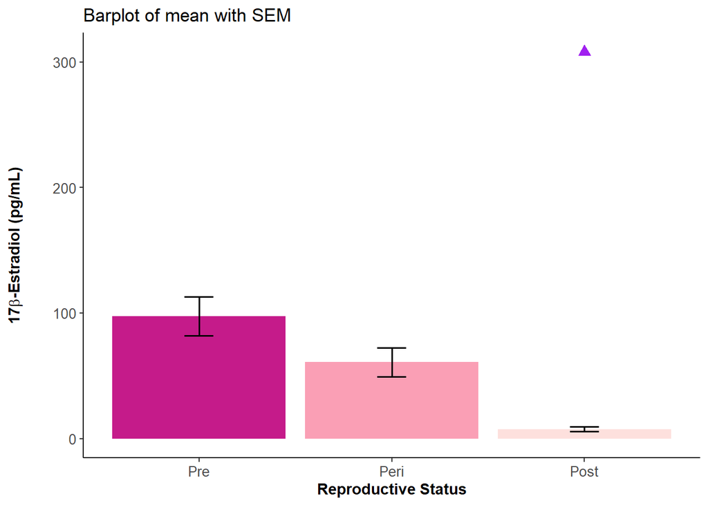

Subject 438: estradiol level of 308 pg/mL

Subject mentioned taking a form of HRT

## Progesterone

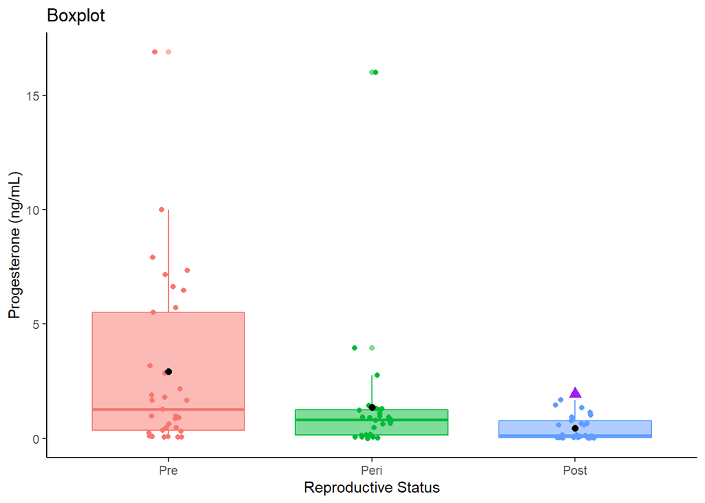

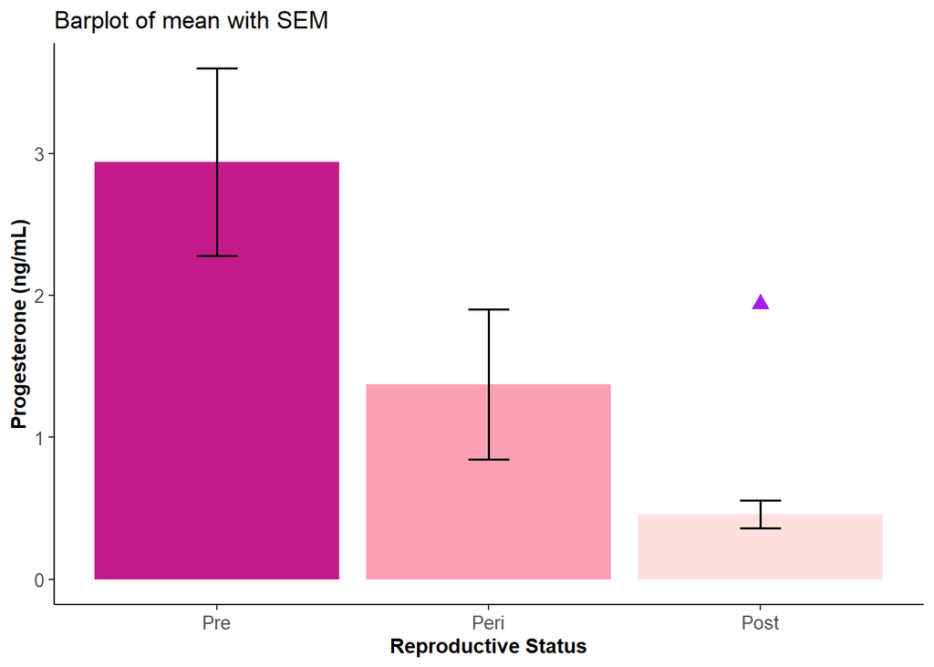

Subject 438: progesterone level of 1.94 ng/mL

## FSH

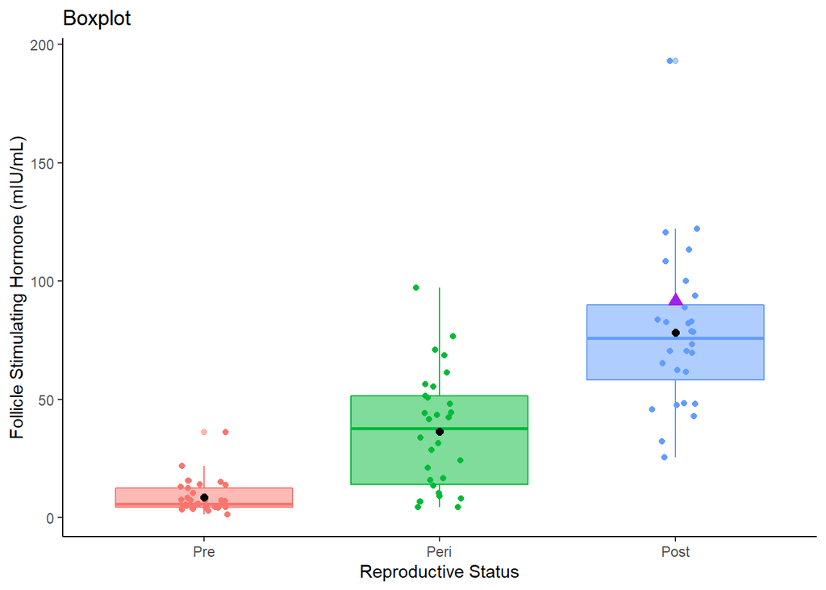

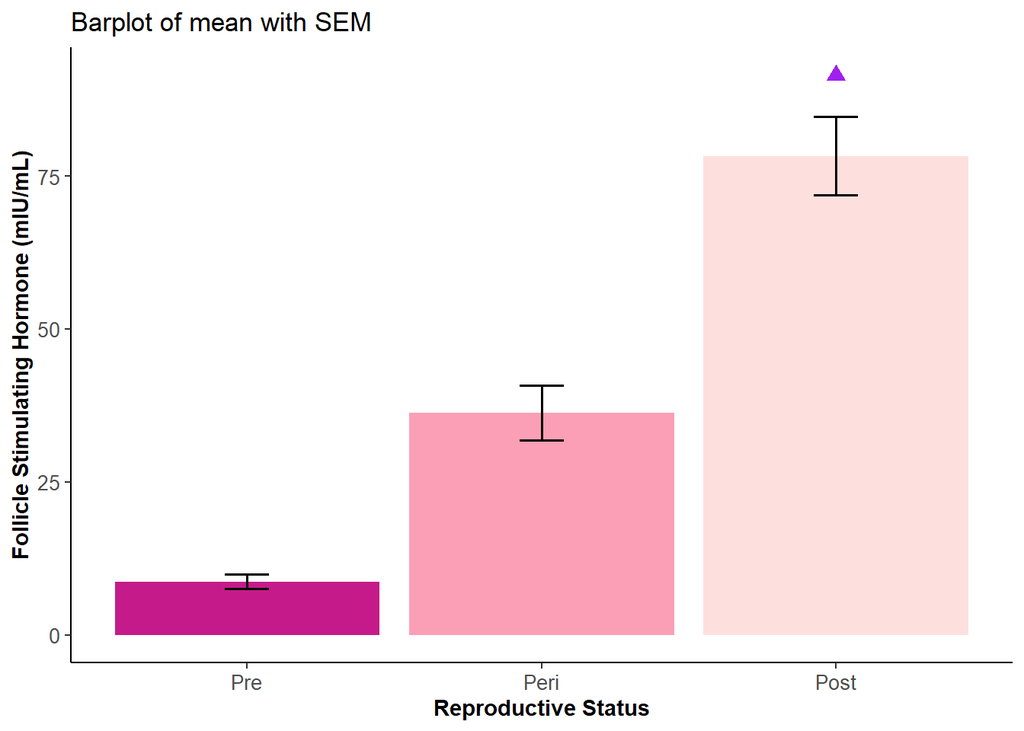

Subject 438: FSH level of 91.5 mIU/mL

## SHBG

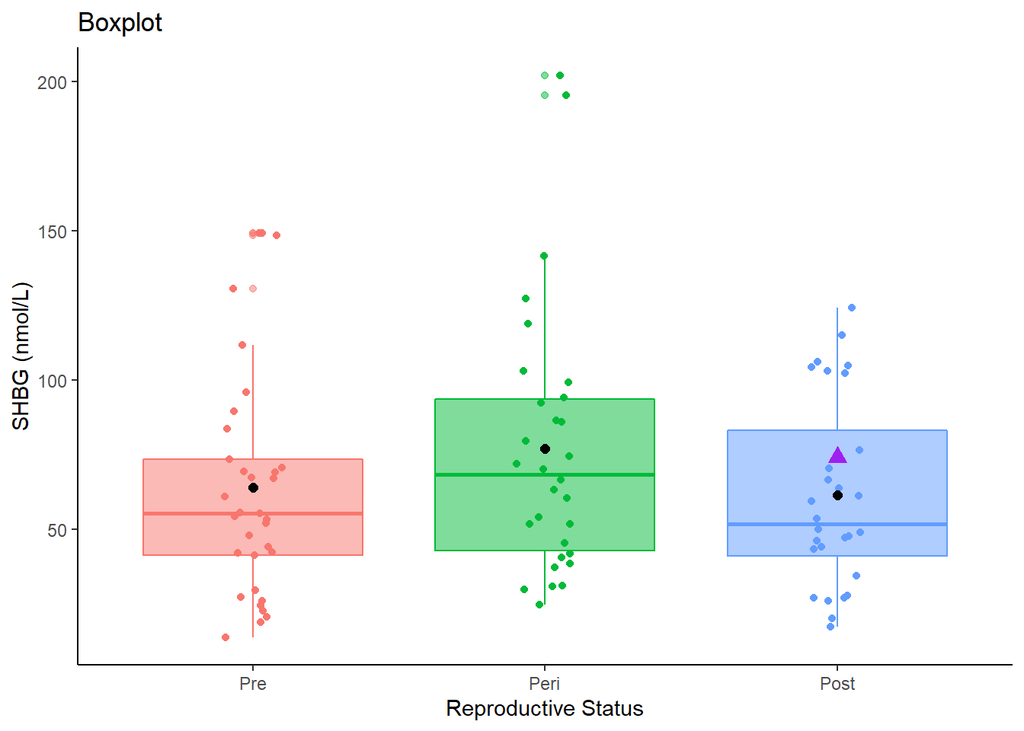

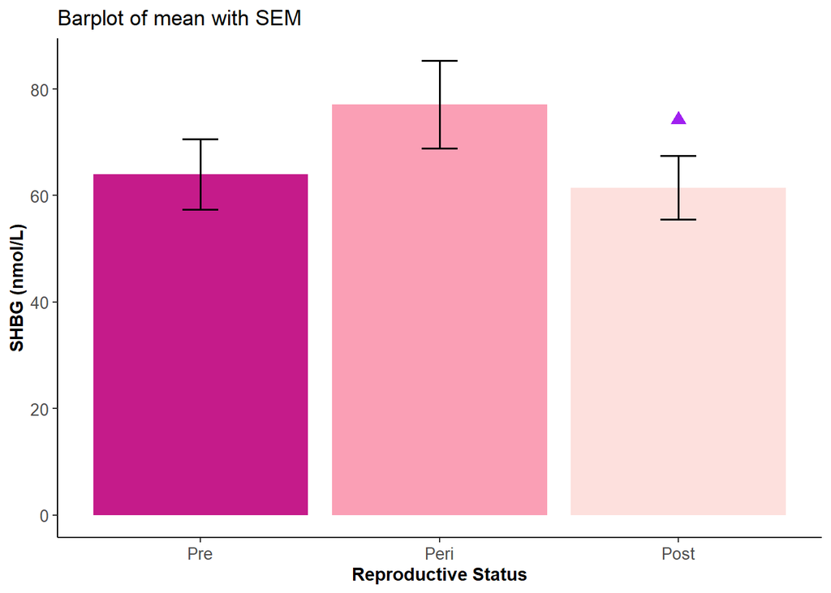

Subject 438: SHBG level of 74.26 nmol/L

## DHEAS

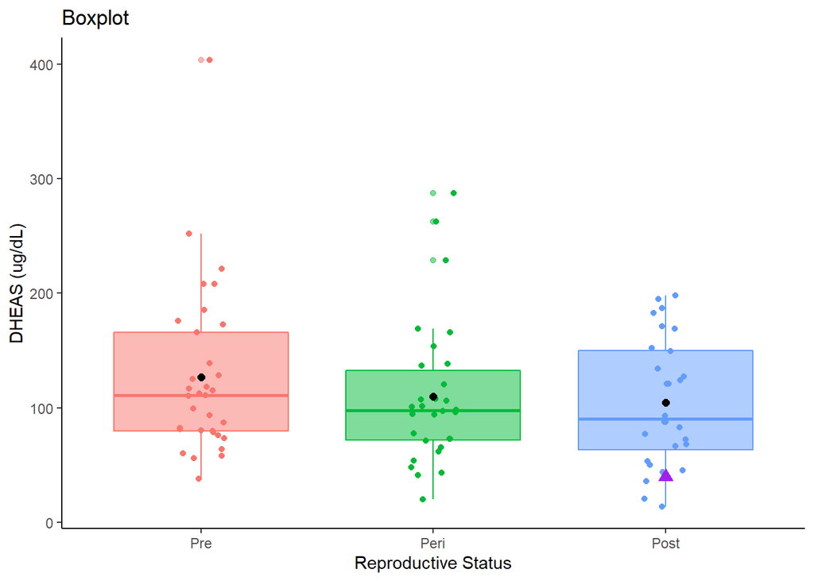

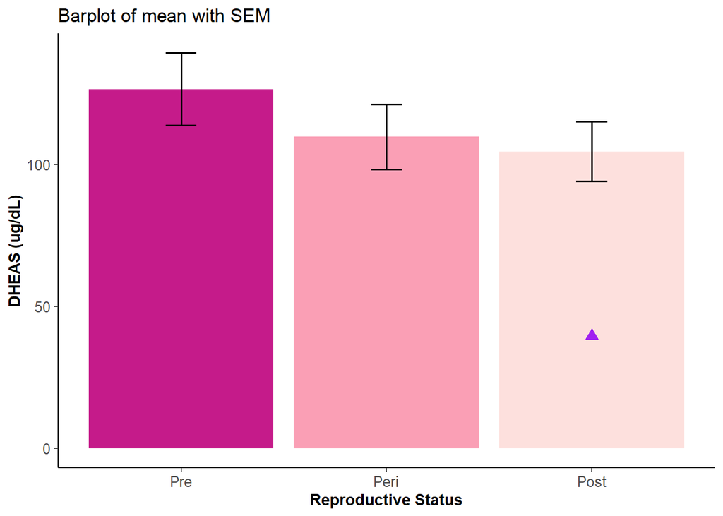

Subject 438: DHEAS level of 39.5 ug/dL

## Testosterone

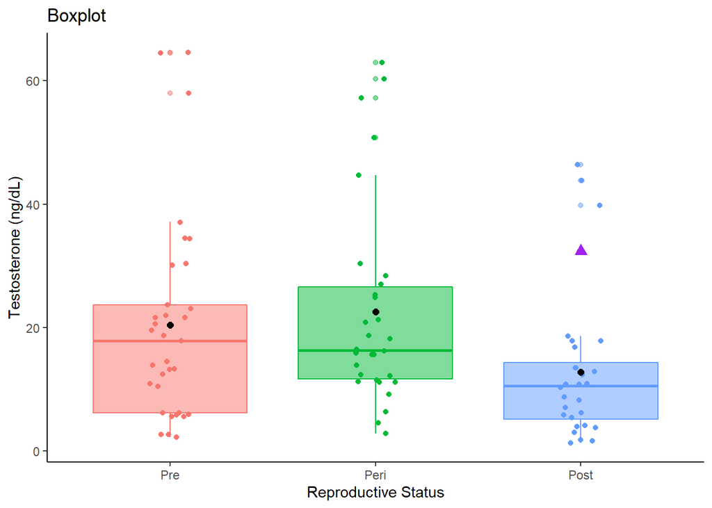

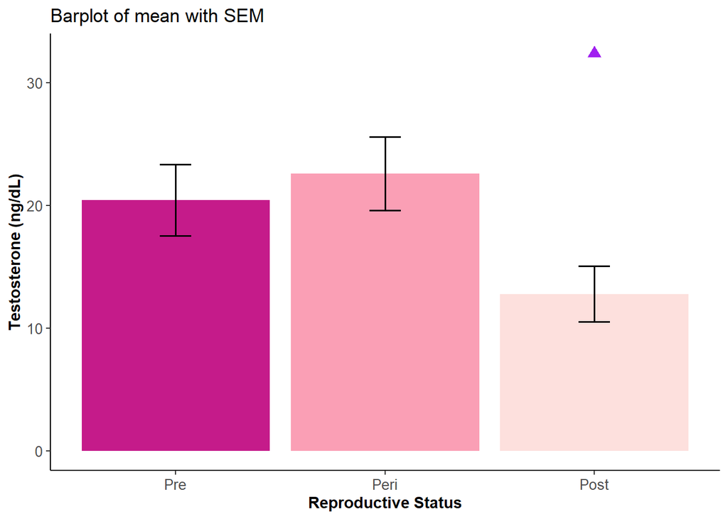

Subject 438: testosterone level of 32.4 ng/dL